# Uygulama Notları: 4

## FİZ219 - Bilgisayar Programlama I | 30/10/2020

**Grafik Çizimi**

- Giriş
- Veriler
- Grafik çizimi
  - Markör çeşitleri
  - Renk çeşitleri
  - Markör boyu
  - Markörün iç ve dış renkleri
    - *Uzun satırlar*
  - Çizgiler
  - Çizgi çeşitleri
  - Çizgi rengi
  - Çizgi kalınlığı
- Gerekli şeyler & süs+püs
  - Başlıklar, tanımlar
  - "Izgara ve keneler"
- Grafiğin sınırları
- Çoklu grafikler
  - Bir ipte iki cambaz (I)
  - *Fonksiyon çizimi*
  - Bir ipte iki cambaz (II)
  - Çok ipte çok cambaz
- Saçılım
  - *Rastgele sayılar*
  - Bonus / Ekstra / Tercihe Bağlı
- Histogram
- 3 Boyutlu Çizimler
- Grafikleri dosyaya yazdırma

Emre S. Tasci emre.tasci@hacettepe.edu.tr

# Giriş

Verilerin grafiksel olarak temsili, bizlere elimizdeki bilgilerin birbirleriyle ilişkileri ve birbirlerine bağlı olarak gelişimleri hakkında bilgi verdiği gibi, arkalarında yatan model ve formülleri de görebilme imkanı sunar. Bunlara ilaveten, grafiklere bakarak, elimizdeki aralıkta ölçümünü yapmadığımız noktalara karşılık gelen değerleri ve dahi aralığın dışındaki yerleri de tahmin edebiliriz: ilk işleme *içdeğer bulma* ("interpolation"); ikinci işleme ise *öteleme* ("extrapolation") denir.

Grafik çizebilmek için, öncelikle, tabii ki, elimizde veriler olması gerekmekte... 8)

Bu dersimizde kullanacağımız veriler, [Horvat & Jecmenica'nın "The free fall experiment" (*Resonance* **21**, 259-275 (2016) | DOI: 10.1007/s12045-016-0321-9)](https://doi.org/10.1007/s12045-016-0321-9) makalesinden alınmıştır.

# Veriler

Elimizde, sınıf ortamında, yerden farklı yüksekliklerden bırakılan bir kütlenin düşme sürelerinin ölçüm verileri var:

| Yükseklik (m) | Düşüş Süresi (s) |
| --- | --- |
| 0.2 | 0.201900 |
| 0.7 | 0.377759 |
| 0.8 | 0.403882 |
| 1.2 | 0.494707 |
| 1.3 | 0.514983 |
| 1.8 | 0.606071 |

İlk iş olarak verileri `veriler` diye bir matrise girip, saklayalım:

```matlab
veriler = [0.2    0.201900
0.7    0.377759
0.8    0.403882
1.2    0.494707
1.3    0.514983
1.8    0.606071] # yukseklik (m) | zaman (s)
```

```
veriler =

   0.20000   0.20190
   0.70000   0.37776
   0.80000   0.40388
   1.20000   0.49471
   1.30000   0.51498
   1.80000   0.60607
```

işlemek kolay olsun diye, 1. sütundaki verilere `y`, 2. sütundakilere de `t` diyelim:

```matlab
y = veriler(:,1)
```

```
y =

   0.20000
   0.70000
   0.80000
   1.20000
   1.30000
   1.80000
```

```matlab
t = veriler(:,2)
```

```
t =

   0.20190
   0.37776
   0.40388
   0.49471
   0.51498
   0.60607
```

# Grafik çizimi

Bir deney yaparken, "kontrol parametresi" dediğimiz, değerini bizim belirleyip, ona göre ölçümler aldığımız parametreyi grafikte yatay eksene (*x-ekseni*) yerleştiririz, kontrol parametresinin farklı değerlerinde ölçtüğümüz değerleri de düşey eksene (*y-ekseni*) işaretleriz.

Verileri aldığımız serbest düşüş deneyinde, kontrol parametresi yükseklik olduğundan, onu yatay eksene, ölçülen parametre olan süre değerlerini ise düşey eksende işaretleyeceğiz.

Octave'da grafik çizdirmek çok pratiktir (hatta o kadar pratiktir ki, Python'a bile neredeyse doğrudan aktarılmıştır (*matplotlib* modülü altında)). Grafik çizdirmek için kullandığımız komut, İngilizce'de *grafik çizmek* anlamına gelen `plot()` komutudur. `plot()` fonksiyonuna girilen birinci parametre yatay eksen değerlerini, ikinci parametre ise düşey eksen değerlerini ifade eder.

Elimizdeki verileri en basit şekilde `plot(y,t)` diyerek çizdiririz:

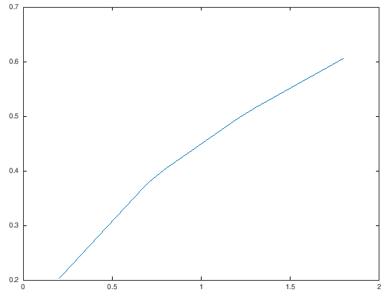

```matlab
plot(y,t)
```

Tebrikler! İlk grafiğinizi çizdiniz. Fakat pek de güzel (/düzgün) görünmüyor gibi sanki. Aslında biraz dikkat bakınca, tablodaki verilerin grafikteki doğruların kırıldıkları noktalar olduğunu görebiliyoruz gibi (gibi)... Tabloyu aşağıya tekrardan alıntılayalım, bir bakın bakalım, siz de kırılma noktalarının oralara geldiğini teyit edebilecek misiniz?

| Yükseklik (m) | Düşüş Süresi (s) |
| --- | --- |
| 0.2 | 0.201900 |
| 0.7 | 0.377759 |
| 0.8 | 0.403882 |
| 1.2 | 0.494707 |
| 1.3 | 0.514983 |
| 1.8 | 0.606071 |

Böyle zor oluyor hakikaten... Onun yerine, verileri grafik üzerinde göstersek?

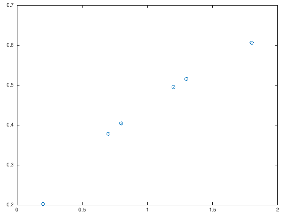

```matlab
plot(y,t,"o")
```

Bence bu şekilde çok daha açık oldu. Fark ettiyseniz, bunu, `plot` fonksiyonuna 3. bir parametre (`"o"`) vererek hallettik. Buna *biçim parametresi* diyoruz ve tırnak içinde belirtiyoruz. `o` dediğimiz için, veri noktalarını temsil eden işaretçikleri ("markörleri") daireler şeklinde gösterdi.

## Markör çeşitleri

Dilersek başka bir sürü şekil markör kullanabiliriz:

| Sembol | İşaret |
| --- | --- |
| + | Artı |
| o | Daire |
| * | Yıldız |
| . | Nokta |
| x | Çarpı |
| s | Kare (**s**quare) |
| d | Paralelkenar/Elmas (**d**iamond) |
| ^ | Sivri ucu yukarıda olan üçgen |
| v | Sivri ucu aşağıda olan üçgen |
| > | Sivri ucu sağda olan üçgen |
| < | Sivri ucu solda olan üçgen |
| p | 5 köşeli yıldız (**p**entagram) |
| h | 6 köşeli yıldız (**h**exagram) |

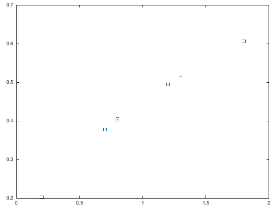

```matlab
# Verileri karelerle temsil edelim:
plot(y,t,"s")
```

Grafiğin biçim parametresinde başka özellikler de tanımlayabiliriz, örneğin rengi.

## Renk çeşitleri

Renkleri hazır tanımlı renkler arasından belirtebiliriz (dilersek 'color' parametresi ile herhangi bir RGB üçlüsü olarak da belirtebiliriz, ama bu aşamada çok gerekli değil).

Hazır tanımlı renklerin listesine gelirsek:

| Sembol | Renk |
| --- | --- |
| k | Siyah (*blac**K***) |
| r | Kırmızı (**R**ed) |
| g | Yeşil (**G**reen) |
| b | Mavi (**B**lue) |
| m | Mor (**M**agenta) |
| c | Turkuaz (**C**yan) |
| w | Beyaz (**W**hite) |

Bu renk sembollerini de doğrudan markör sembolünün yanına yazıyoruz - çakışma olmadığı için hangisini önce yazdığımızın bir önemi yok, yeter ki aynı tırnak işaretinin içerisinde olsunlar: örneğin `"xr"` de, `"rx"` de, bize kırmızı çarpılı markörler çıkartır:

[figure not shown]

```matlab
# Kırmızı çarpılar
plot(y,t,"rx")
```

## Markör boyu

Çarpılar biraz küçük gibi görünüyor, büyütme işini `"markersize"` (*markör boyu*) parametresi ile yapıyoruz. Bu parametre markör şekli ve renginden biraz farklı bir şekilde tanımlanıyor yalnız: önce parametreyi, ardından değeri giriyoruz şu şekilde:

[figure not shown]

```matlab
# Kırmızı büyük çarpılar
plot(y,t,"rx","markersize",10)
```

## Markörün iç ve dış renkleri

Eğer daire, kare veya yıldız gibi içi olan bir markör kullanıyorsak, içinin ve kontürünün renklerini sırasıyla `"markerfacecolor"` ve `"markeredgecolor"` parametreleriyle ayrı ayrı belirleyebiliriz.

Örneğin, içi yeşil, dışı kırmızı daireler kullanalım:

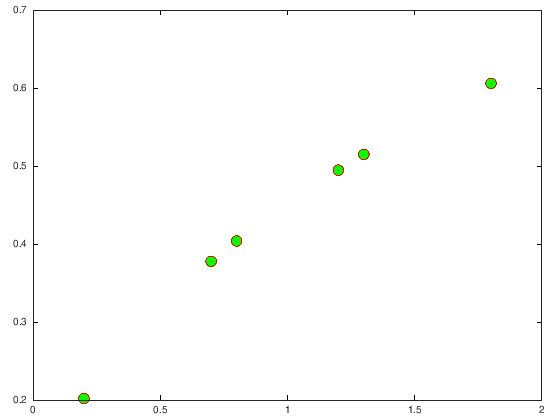

```matlab
plot(y,t,"o","markersize",10,"markerfacecolor","g","markeredgecolor","r")
```

### Uzun satırlar

Octave'da uzun satırları bölmek için `...` operatörü kullanılır. Yukarıdaki uzun komutu, iki satıra bölmek isteseydik:

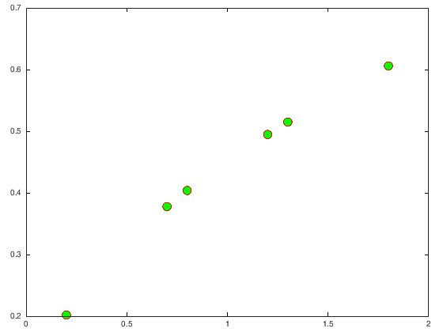

```matlab
plot(y,t,"o","markersize",10,...
         "markerfacecolor","g","markeredgecolor","r")
```

şeklinde yazabilirdik (boşluklar önemli olmadığından, alt satırlara geçtiğimizde yazmaya başlamadan önce istediğimiz kadar boşluk bırakabiliriz). Bu taktiği çok fazla elemanı olan dizileri yazmak için de kullanabiliriz:

```matlab
cok_elemanli_dizi = [123,321,123,321,432,543,...
  213,12,34,65,834,23,543,234,2343,4234,432,...
  23423,432423,42342,342,432423,432,234,324]
```

```
cok_elemanli_dizi =

 Columns 1 through 8:

      123      321      123      321      432      543      213       12

 Columns 9 through 16:

       34       65      834       23      543      234     2343     4234

 Columns 17 through 24:

      432    23423   432423    42342      342   432423      432      234

 Column 25:

      324
```

## Çizgiler

Markörleri iyice kavradığımıza göre, grafiklerimize biraz daha çeşitlilik katalım. Veri noktalarımızı çizgi ile birleştirmek için, biçim kısmına en temel halde bir `-` sembolü ekleriz:

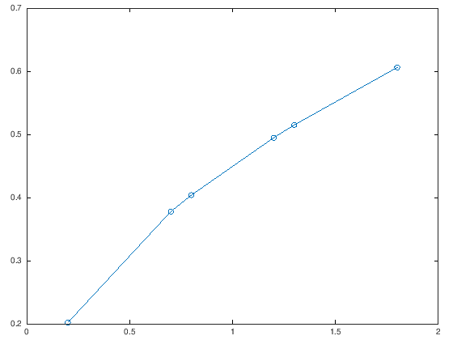

```matlab
plot(y,t,"o-")
```

Biçimde iki paremetre belirledik, "o" ile "-": ilki veri noktalarını daireler ile temsil edilmesini, ikincisi de bu veri noktalarının düz çizgi ile birleştirilmesini belirtmekte (hatırlarsanız, ilk çizdirdiğimiz grafikte (`plot(y,t)`) veri noktaları ayrıca gösterilmemiş, sadece doğrudan çizgilerle araları birleştirilmişti).

Her şeye olduğu gibi, çizgi biçimlerine de müdahale edebiliyoruz: çizgilerimizin çeşitlerini (düz, kesikli, nokta nokta, çizgi-nokta); rengini, kalınlığını, onlara karşılık gelen anahtar kelime / sembollerle ayarlayabiliriz.

## Çizgi Çeşitleri

Yukarıda da yazdığımız üzere, 4 farklı çeşit çizgi ile çalışabiliriz:

| Sembol | Çizgi çeşidi |
| --- | --- |
| - | Düz çizgi |
| -- | Kesikli çizgi |
| : | Nokta nokta |
| -. | Çizgi-nokta |

Nasıl göründüklerini altta topluca inceleyebilirsiniz (o 2x2 grafiği nasıl çizdirdiğimizi (*subplot*) de birazdan göreceğiz ;) :

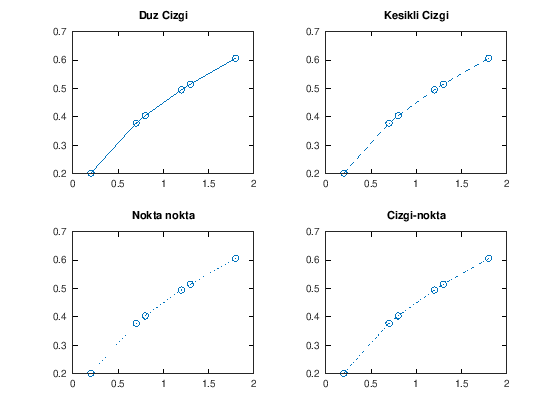

```matlab
subplot(2,2,1)
 plot(y,t,"o-")
 title("Duz Cizgi")
subplot(2,2,2)
 plot(y,t,"o--")
 title("Kesikli Cizgi")
subplot(2,2,3)
 plot(y,t,"o:")
 title("Nokta nokta")
subplot(2,2,4)
 plot(y,t,"o-.")
 title("Cizgi-nokta")
```

## Çizgi Rengi

Aslında en başından beri grafikleri çizerken, normal renk parametresi (örn. "or"'deki "r") olarak belirttiğimiz renk, temel olarak çizgi rengidir, markörlerin rengi de ("markerfacecolor" ve/veya "markeredgecolor" ile) aksi belirtilmedikçe bu renkte çizilir.

Yani, grafiğimizi mavi kesikli çizgi üzerine dışı kırmızı, içi yeşil dairesel markörlerle çizdirmek istersek, bunu şu şekilde yaparız:

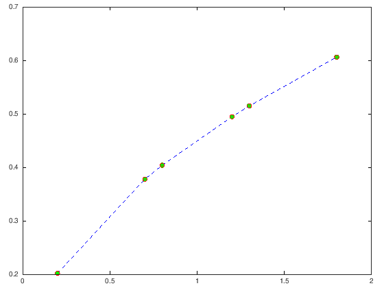

```matlab
plot(y,t,"b--o","markerfacecolor","g","markeredgecolor","r")
```

## Çizgi kalınlığı

Çizgi kalınlığını da `linewidth` parametresi ile belirtiriz. Yukarıdaki grafiği daha kalın çizgilerle çizmek için:

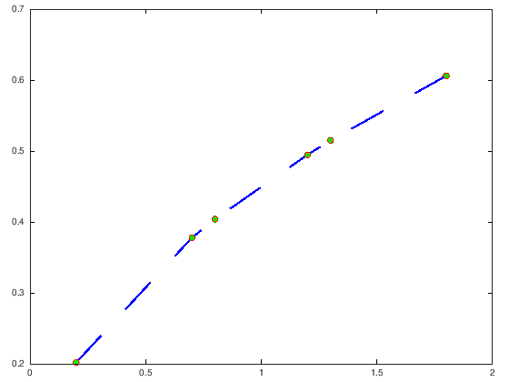

```matlab
plot(y,t,"b--o","markerfacecolor","g","markeredgecolor","r",...
     "linewidth",4)
```

Markörler çizgilerin yanında biraz küçük kaldı, onları da coşturup, bu konuyu kapatalım:

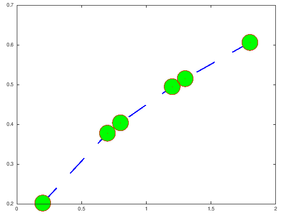

```matlab
plot(y,t,"b--o","markerfacecolor","g","markeredgecolor","r",...
     "linewidth",4,"markersize",30)
```

# Gerekli şeyler & süs+püs

Grafiklerimiz bu şekilde *matematiksel olarak* grafik olsalar da, fiziksel açıdan pek de işe yarar şeyler değiller: Neyin grafiği bu? Yatay ve düşey eksenler neyi temsil ediyor, birimleri nedir? Veri noktaları tam olarak neye karşılık geliyor? Bu noktada devreye grafik tanımlayıcıları girer.

## Başlıklar, tanımlar

Eksenlerin tanımlarını `xlabel()` ve `ylabel()` fonksiyonları ile ve **grafiği `plot` ile çizdirdikten sonra** belirtiriz. `title()` fonksiyonu ile de grafiğimizin başlığını yazarız. Örneğimiz üzerinde çalışalım, çok daha anlaşılır olacak:

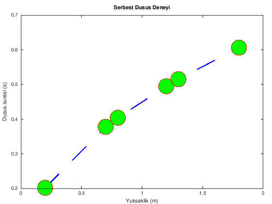

```matlab
# Grafiğimizi çizdiriyoruz
plot(y,t,"b--o","markerfacecolor","g","markeredgecolor","r",...
     "linewidth",4,"markersize",30)

# Tanımlamaları yapıyoruz
xlabel("Yukseklik (m)")
ylabel("Dusus suresi (s)")
title("Serbest Dusus Deneyi")
```

## "Izgara ve keneler" 8P

Grafik üzerindeki verilerimizin değerleri rahatça anlaşılıp, kıyaslanabilsin diye, eksenleri böldüğümüz aralıklardan çizgiler uzatırız. Bu kontrolü `grid` komutu ile gerçekleştiriyoruz:

- `grid on` bu çizgilerin görüntülenmesini açar
- `grid off` da kapar

Eksenler üzerindeki hangi değerlerin hangi aralıklarla (örneğin yukarıdaki grafikte yatay eksen 0'dan 2'ye 0.5'lik aralıklarla; düşey eksen ise 0.2'den 0.7'ye 0.1'lik aralıklarla bölünmüş durumda) bölüneceğini, ya da bir başka deyişle çentik konumlarını ise sırasıyla `xticks()` ve `yticks()` fonksiyonları ile belirtiriz.

Yukarıdaki örnek üzerinde çalışmaya devam edersek, önce ızgarayı (*grid*'i) açalım:

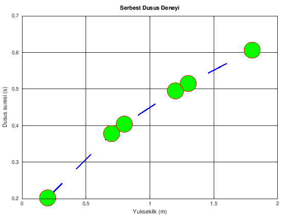

```matlab
# Grafiğimizi çizdiriyoruz
plot(y,t,"b--o","markerfacecolor","g","markeredgecolor","r",...
     "linewidth",4,"markersize",30)

# Tanımlamaları yapıyoruz
xlabel("Yukseklik (m)")
ylabel("Dusus suresi (s)")
title("Serbest Dusus Deneyi")

# Izgarayı açalım
grid on
```

sonrasında da yatay ve düşey eksendeki çentikleri (*ticks*) sıklaştıralım:

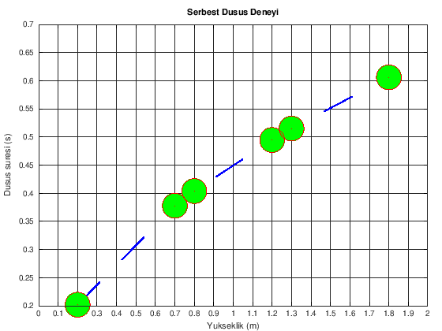

```matlab
# Grafiğimizi çizdiriyoruz
plot(y,t,"b--o","markerfacecolor","g","markeredgecolor","r",...
     "linewidth",4,"markersize",30)

# Tanımlamaları yapıyoruz
xlabel("Yukseklik (m)")
ylabel("Dusus suresi (s)")
title("Serbest Dusus Deneyi")

# Izgarayı açalım
grid on

# Çentikleri yeniden tanımlayalım
xticks(0:0.1:2)
yticks(0.2:0.05:0.7)
```

Grafik aynı grafik olsa da, okunabilirliği epey artmış oldu. Çentik tanımlamasını yaparken, geçen dersimizde tanıştığımız aralık operatörünü (*başlangıç:adım uzunluğu:bitiş*) kullandığımıza dikkatinizi çekerim.

Pek sık karşılaşılmasa da, çentikleri dilerseniz kafanıza göre, eşit olmayan aralıklarla da tanımlayabilirsiniz:

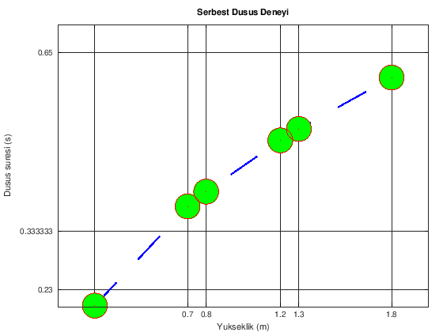

```matlab
# Grafiğimizi çizdiriyoruz
plot(y,t,"b--o","markerfacecolor","g","markeredgecolor","r",...
     "linewidth",4,"markersize",30)

# Tanımlamaları yapıyoruz
xlabel("Yukseklik (m)")
ylabel("Dusus suresi (s)")
title("Serbest Dusus Deneyi")

# Izgarayı açalım
grid on

# Çentikleri yeniden tanımlayalım

# Yatay eksendekiler için sadece veri noktalarını
xticks([0.2, 0.7, 0.8, 1.2, 1.3, 1.8])

# Düşey eksendekiler içinse kafamıza göre alalım...
yticks([0.23,1/3,0.65])
```

(tahmin edebileceğiniz üzere, yatay eksendeki çentikleri tek tek yazmak yerine, doğrudan `xticks(y)` de diyebilirdik - ne de olsa `y` değişkeni doğal olarak yukarıda girdiğimiz veri noktalarını tutmakta ;)

# Grafiğin sınırları

Grafiğimizin çizim sınırlarını `axis()` fonksiyonu ile belirliyoruz. Parametre olarak bir dizi alır ve dizinin eleman sayısı 2 ise bunlar yatay eksenin minimum ve maksimum değerlerini; 4 elemanlı bir dizi ise o zaman da dizinin elemanlarını sırasıyla yatay eksenin minimum ve maksimum değerleri ve düşey eksenin minimum ve maksimum değerleri olarak yorumlar.

Yukarıdaki örneğimizi önce bir düzgün çizdirelim:

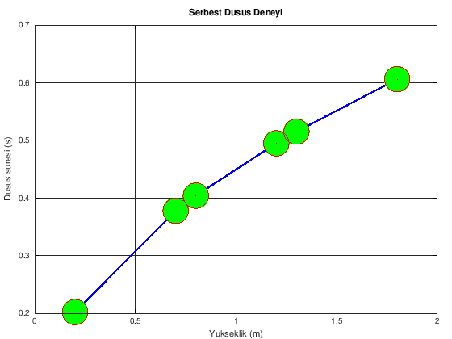

```matlab
# Grafiğimizi çizdiriyoruz
plot(y,t,"b-o","markerfacecolor","g","markeredgecolor","r",...
     "linewidth",4,"markersize",30)

# Tanımlamaları yapıyoruz
xlabel("Yukseklik (m)")
ylabel("Dusus suresi (s)")
title("Serbest Dusus Deneyi")

# Izgarayı açalım
grid on
```

Yatay eksenin gösterim aralığını [-1,3], düşey eksen aralığını ise [0,1] yapalım:

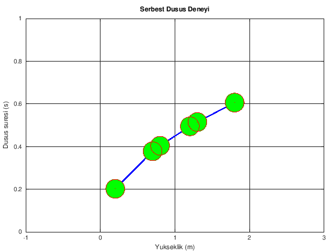

```matlab
# Grafiğimizi çizdiriyoruz
plot(y,t,"b-o","markerfacecolor","g","markeredgecolor","r",...
     "linewidth",4,"markersize",30)

# Tanımlamaları yapıyoruz
xlabel("Yukseklik (m)")
ylabel("Dusus suresi (s)")
title("Serbest Dusus Deneyi")

# Izgarayı açalım
grid on

axis([-1,3,0,1])
```

# Çoklu grafikler

## Bir ipte iki cambaz (I)

Bir grafik üzerinde iki veri setini göstermek için, sanki iki ayrı grafik çizdirecekmişiz gibi tanımlayıp, sonra bunları aynı `plot()` fonksiyonu içerisinde birleştiririz.

Ders boyunca kullanageldiğimiz veri setini hatırlayalım:

```matlab
veriler
```

```
veriler =

   0.20000   0.20190
   0.70000   0.37776
   0.80000   0.40388
   1.20000   0.49471
   1.30000   0.51498
   1.80000   0.60607
```

Bu serbest düşüş deneyini ellerinde kronometre olmadığından, süreyi saatin saniye kısmıyla ölçen ikinci bir grubun da yapmış olduğunu ve şu sonuçarı aldığını varsayalım:

```matlab
veriler_2 = [0.20000   0.3
   0.70000   0.4
   0.80000   0.4
   1.20000   0.5
   1.30000   0.6
   1.80000   0.7]

# 2. sütunu t_2 değişkenine atayalım
t_2 = veriler_2(:,2)

# (y değerleri (1.sütun) ilk veri setiyle
# aynı olduğundan, onu ayrıca bir y_2 değişkenine
# atamadık)
```

```
veriler_2 =

   0.20000   0.30000
   0.70000   0.40000
   0.80000   0.40000
   1.20000   0.50000
   1.30000   0.60000
   1.80000   0.70000

t_2 =

   0.30000
   0.40000
   0.40000
   0.50000
   0.60000
   0.70000
```

Normalde, ikisini ayrı ayrı çizdirecek olsak:

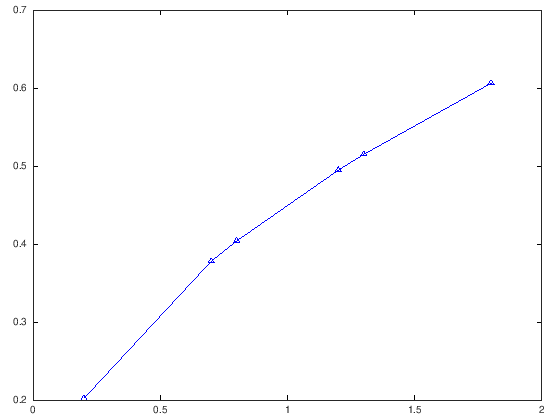

```matlab
plot(y,t,"^-b") # 1. grafik
```

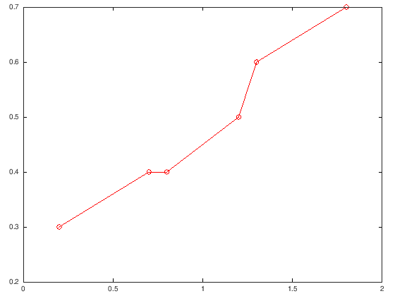

```matlab
plot(y,t_2,"o-r") # 2. grafik
```

Şeklinde yazardık. Aynı grafik üzerinde ikisini birlikte çizdirmek içinse tek bir `plot()` fonksiyonunda birleştiriyoruz (birleştirirken aralarına virgül koyuyoruz):

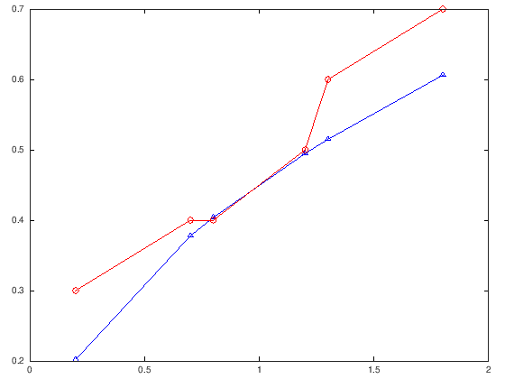

```matlab
# plot(y,t,"^-b") ve plot(y,t,"o-r") yerine:
plot(y,t,"^-b",y,t_2,"o-r")
```

Hangisinin hangisi olduğunun açıklamasını ise `legend()` komutu ile belirtebiliriz (hazır yapıyorken, tanımları da koyalım):

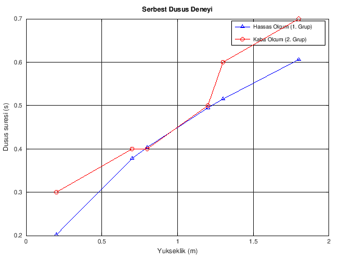

```matlab
plot(y,t,"^-b",y,t_2,"o-r")
xlabel("Yukseklik (m)")
ylabel("Dusus suresi (s)")
title("Serbest Dusus Deneyi")

legend("Hassas Olcum (1. Grup)","Kaba Olcum (2. Grup)")

# Izgarayı açalım
grid on
```

Yukarıdaki grafikte gördüğünüz üzere, açıklama kutusu verilerle çakıştı. Bu tür durumlarda kutuyu 8 uç yöne taşımak için `"location"` parametresini devreye sokabiliriz. Parametre değerleri olarak 8 temel yönün İngilizce karşılıkları (*"north", "south", "east", "west", "northeast", "northwest", "southeast", "southwest"*) kullanılır. Örneğimizdeki kutucuğu sol-üste, yani "kuzeybatı"ya taşıyalım:

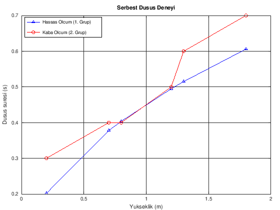

```matlab
plot(y,t,"^-b",y,t_2,"o-r")
xlabel("Yukseklik (m)")
ylabel("Dusus suresi (s)")
title("Serbest Dusus Deneyi")

legend("Hassas Olcum (1. Grup)","Kaba Olcum (2. Grup)",...
       "location","northwest")

# Izgarayı açalım
grid on
```

Kutucuğu tümden grafiğin dışına almak içinse `location` parametresinin değerine *dışarı* anlamına gelen `outside` terimini yamarız:

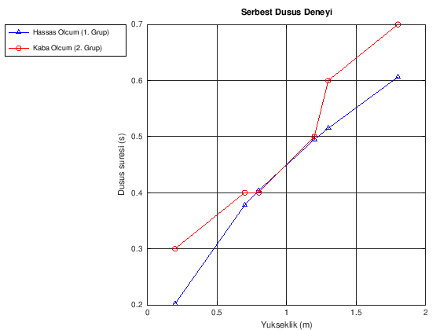

```matlab
plot(y,t,"^-b",y,t_2,"o-r")
xlabel("Yukseklik (m)")
ylabel("Dusus suresi (s)")
title("Serbest Dusus Deneyi")

legend("Hassas Olcum (1. Grup)","Kaba Olcum (2. Grup)",...
       "location","northwestoutside")

# Izgarayı açalım
grid on
```

`legend` parametresi ile başka birçok şey daha yapmak mümkün, detaylar için [ilgili komutun açıklama sayfasına](https://octave.sourceforge.io/octave/function/legend.html) göz atabilirsiniz.

## Fonksiyon çizimi

Octave, temel olarak sembolik bir dil olmadığı için, fonksiyon çizdirirken de fonksiyonun belli yerlerdeki değerlerinden bir veri dizisi oluşturup, onların grafiğini çizdiririz.

Örneğin $y = x^2$ grafiğini $x\in[0,1]$ aralığı için çizdirelim.

- Öncelikle bu aralıktaki x değerlerini tanımlarız:

```matlab
x = 0:0.2:1
```

```
x =

    0.00000    0.20000    0.40000    0.60000    0.80000    1.00000
```

- Sonrasında $y$ değerlerini $x$ değerleri üzerinden tanımlarız:

```matlab
y = x.**2
```

```
y =

   0.00000   0.04000   0.16000   0.36000   0.64000   1.00000
```

(üs alma operatöründen önce "." sembolünü koyarak, x vektörünün karesini değil, eleman bazında kare alma işlemini gerçekleştirdiğimizi belirttik - aman dikkat!)

Grafiğimizi artık çizdirebiliriz:

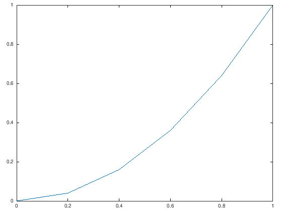

```matlab
plot(x,y,"-")
```

Pek kesik kesik görünüyor. Bunun sebebi ele aldığımız değer adedi. 6 parça ([0, 0.2, 0.4, 0.6, 0.8, 1]) ile ancak bu kadar oluyor. Arttıralım bakalım, neye benzeyecek...

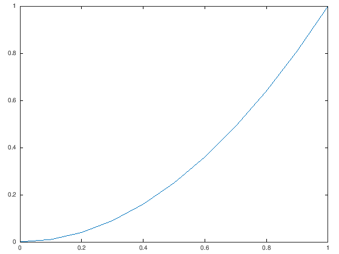

```matlab
x = 0:0.1:1;
y = x.**2;
plot(x,y)
```

Epey düzelme var. peki aralığı 125 çentiğe ayırmak istesek? Aralık operatörü ile bunu yapmak mümkün ama oturup adım uzunluğunu hesaplamak gerekecek. Bu tür durumlarda ise yardımımıza, aralık operatörünün kardeşi `linspace()` fonksiyonu yetişiyor. `linspace` ile başlangıç ve bitiş değerlerini verip, kaç çentik istediğimizi bildiriyoruz, o da eşit aralıklara bölüp, bize çentikleri döndürüyor.

Örneğin: 0 ile 1 arasını 3 çentikle bölelim:

```matlab
linspace(0,1,3)
```

```
ans =

   0.00000   0.50000   1.00000
```

Grafiğimizi bu sefer 125 çentikle çizelim:

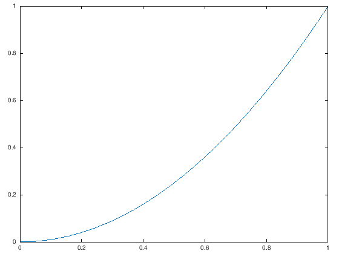

```matlab
x = linspace(0,1,125);
y = x.**2;
plot(x,y)
```

Aynı grafik üzerinde $y_1 = x$ ve $y_2 = x^2$ grafiklerini güzelce çizdirelim:

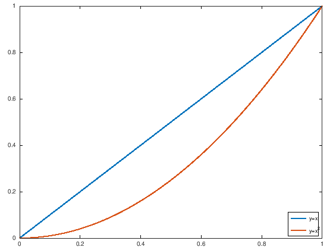

```matlab
x = linspace(0,1,125);
y_1 = x;
y_2 = x.**2;
plot(x,y_1,"linewidth",4,x,y_2,"linewidth",4)
legend("y=x","y=x^2","location","southeast")
```